# How to keep it togetheR

2019-05-09

Using list-columns - R Cafe UU, 28 January 2019

## Prerequisites

- Intro base R
- Data wrangling
- Visualizations
- Writing functions
- Loops
- Pipes (`%>%`)

## Credits

Much of this material has been derived in one way or the other from the work of Hadley Wickham and Garret Grolemund and many others. For a more elaborate reference list see the REFERENCES.txt file in the project root.

Thanks to Hadley & Garret for writing the book “R for Data Science” http://r4ds.had.co.nz/ and for their work in general to innovate the R world.

Work on integration of Git/Github with R/RStudio is thoroughly and wit-fully documented by Jenny Brian. I also very much appreciate her work on the use of RMarkdown. See also:

https://github.com/jennybc/happy-git-with-r & http://stat545.com/block007_first-use-rmarkdown.html

## Contents

List columns and managing many models with `{tidyverse}`

1. Quick R recap
2. Loops in R
3. Using list colums (in a dataframe)
4. Implementing list columns to create models and graphs

## Functional programming in R

- Writing your own functions
- Automate routine tasks
- Prerequisite for writing R packages
- Prerequisite for increasing reproducibility

## Iterations

- Iterate a function over a number of elements/objects
- `for`-loops are not bad
- `map` (or `apply`) family of functions are specials for iteration
- Iterations and writing functions go hand-in-hand

## Packages

```r
library(tidyverse)
library(modelr)
library(lubridate)
library(broom)
```

## Case data

## Data origin

Whooping cough outbreaks from The World Health Organization

http://data.euro.who.int/cisid/?TabID=463987

See for variable and data collection also:

http://ecdc.europa.eu/sites/portal/files/documents/Pertussis%20AER.pdf

## Data gathering

The data used in this presentation has been constructed from the interactive database tool hosted at: http://data.euro.who.int/cisid/ A selection was made for all available countries and all avaialable years, for the number of cases reported to the WHO for Whooping Cough - **Bordetella pertussis** - infections. The file is available in CSV format in `./data/CISID_pertussis_10082018.csv`

## Data characteristics

- The first few lines of the file have comments indicated with `#`
- There are 53 countries in the dataset
- There is data from 1991 to 2013
- The data is not in `tidy` format
- Missing values are indicated with *`NA`*

## **Discuss with your neighbour**

- What makes this data untidy?
- Why is it not a good idea to have a column name starting with a digit?

## Read data into R

```r
pertussis_data <- read_csv(
  file = file.path(root,
  "data",
  "CISID_pertussis_10082018.csv"),
  comment = "#",
  n_max = 53,
  na = c("", " ")
  )
```

## Inspect data

```r
head(pertussis_data, n = 2)
```

```
## # A tibble: 2 x 41
##      X1 X2    `1980` `1981` `1982` `1983` `1984` `1985` `1986` `1987`
##   <dbl> <chr> <lgl>  <lgl>  <lgl>  <lgl>  <lgl>  <lgl>  <lgl>  <lgl>
## 1     2 Alba~ NA     NA     NA     NA     NA     NA     NA     NA
## 2     5 Ando~ NA     NA     NA     NA     NA     NA     NA     NA
## # ... with 31 more variables: `1988` <lgl>, `1989` <lgl>, `1990` <dbl>,
## #   `1991` <dbl>, `1992` <dbl>, `1993` <dbl>, `1994` <dbl>, `1995` <dbl>,
## #   `1996` <dbl>, `1997` <dbl>, `1998` <dbl>, `1999` <dbl>, `2000` <dbl>,
## #   `2001` <dbl>, `2002` <dbl>, `2003` <dbl>, `2004` <dbl>, `2005` <dbl>,
## #   `2006` <dbl>, `2007` <dbl>, `2008` <dbl>, `2009` <dbl>, `2010` <dbl>,
## #   `2011` <dbl>, `2012` <dbl>, `2013` <dbl>, `2014` <lgl>, `2015` <lgl>,
## #   `2016` <lgl>, `2017` <lgl>, `2018` <lgl>
```

```r
names(pertussis_data)
```

```
##  [1] "X1"   "X2"   "1980" "1981" "1982" "1983" "1984" "1985" "1986" "1987"
## [11] "1988" "1989" "1990" "1991" "1992" "1993" "1994" "1995" "1996" "1997"
## [21] "1998" "1999" "2000" "2001" "2002" "2003" "2004" "2005" "2006" "2007"
## [31] "2008" "2009" "2010" "2011" "2012" "2013" "2014" "2015" "2016" "2017"
## [41] "2018"
```

## The pipe

**%>%** (`infix function from the {magrittr} package`)

`some_object %>% function_that_does_something_to_the_object()`

equivalent to:

`function_that_does_something_to_the_object(some_object)`

Avoid recursive use of brackets, use the pipe

**“Write code for humans and computers”**

## Tidy the data

```r
source(file = file.path(root,
                        "code",
                        "do_tidy_pertussis.R"))
```

## Recap ‘R Objects’

## R vectors

- Vectors are the building blocks of everything that is `R`
- There are two flavours: `atomic` vectors and `recursive` vectors (lists)
- `atomic` vectors are homogenous, `recursive vectors` can be heterogenous

## Atomic vectors

- The shortest vector is `NULL`, the longest is `inf`, the weirdest is `Nan`

```r
(28/0) / (28/0)
```

```
## [1] NaN
```

- A single element is also a vector
- Columns of a tabular data structure are also vectors

## Proof of the pudding is in the eating

Atomic vectors

```r
null <- NULL
is.vector(null)
```

```
## [1] FALSE
```

```r
inf <- Inf
is.vector(inf)
```

```
## [1] TRUE
```

```r
nan <- NaN
is.vector(nan)
```

```
## [1] TRUE
```

```r
single_element <- 1
is.vector(single_element)
```

```
## [1] TRUE
```

## Recursive vectors

```r
table <- tribble(
  ~ a, ~b, ~c, ~d,
  "x", 1, TRUE, 1.45,
  "y", 2, FALSE, 3.88,
  "z", 3, TRUE, 33.5
  ) %>%
  as_tibble()
table
```

```
## # A tibble: 3 x 4
##   a         b c         d
##   <chr> <dbl> <lgl> <dbl>
## 1 x         1 TRUE   1.45
## 2 y         2 FALSE  3.88
## 3 z         3 TRUE  33.5
```

## Checking characteristics of `table`

```r
is.vector(table)
```

```
## [1] FALSE
```

```r
is.vector(table$a)
```

```
## [1] TRUE
```

```r
is.atomic(table)
```

```
## [1] FALSE
```

```r
is.atomic(table$c)
```

```
## [1] TRUE
```

```r
is.recursive(table)
```

```
## [1] TRUE
```

```r
class(table)
```

```
## [1] "tbl_df"     "tbl"        "data.frame"
```

```r
typeof(table)
```

```
## [1] "list"
```

```r
## So dataframes are a special kind of lists?!?
```

## **Discuss with your neighbour**

What is going on with the code below?

```r
table[1]
```

```
## # A tibble: 3 x 1
##   a
##   <chr>
## 1 x
## 2 y
## 3 z
```

```r
table[[1]]
```

```
## [1] "x" "y" "z"
```

## Data frames, Tibbles, and List Columns

```r
data.frame(a = c(1, 2, 3.14),
           b = c("a", "b", "c"),
           c = c(TRUE, FALSE, FALSE)) %>%
  print()
```

```
##      a b     c
## 1 1.00 a  TRUE
## 2 2.00 b FALSE
## 3 3.14 c FALSE
```

## A list-column in a ‘normal’ dataframe

```r
data.frame(a = c(1, 2, 3.14),
           b = c("a", "b", "c"),
           c = c(TRUE, FALSE, FALSE),
           d = list(p = 1:3, q = TRUE, r = 0L)) %>%
  print()
```

```
##      a b     c d.p  d.q d.r
## 1 1.00 a  TRUE   1 TRUE   0
## 2 2.00 b FALSE   2 TRUE   0
## 3 3.14 c FALSE   3 TRUE   0
```

## Add list column with `$`

```r
z <- data.frame(a = c(1, 2, 3.14),
                b = c("a", "b", "c"),
                c = c(TRUE, FALSE, FALSE))
z$d <- list(p = 1:30, q = TRUE, r = 0L)
print(z)
```

```
##      a b     c
## 1 1.00 a  TRUE
## 2 2.00 b FALSE
## 3 3.14 c FALSE
##                                                                                                               d
## 1 1, 2, 3, 4, 5, 6, 7, 8, 9, 10, 11, 12, 13, 14, 15, 16, 17, 18, 19, 20, 21, 22, 23, 24, 25, 26, 27, 28, 29, 30
## 2                                                                                                          TRUE
## 3                                                                                                             0
```

```r
## prints messy to the Console
```

## `tibble` for nicer printing

```r
library(tibble)
z <- as_tibble(z)
print(z)
```

```
## # A tibble: 3 x 4
##       a b     c     d
##   <dbl> <fct> <lgl> <list>
## 1  1    a     TRUE  <int [30]>
## 2  2    b     FALSE <lgl [1]>
## 3  3.14 c     FALSE <int [1]>
```

## Create tibble directly

```r
tibble(a = c(1, 2, 3.14),
       b = c("a", "b", "c"),
       c = c(TRUE, FALSE, FALSE),
       d = list(p = 1:3, q = TRUE, r = 0L))
```

```
## # A tibble: 3 x 4
##       a b     c     d
##   <dbl> <chr> <lgl> <list>
## 1  1    a     TRUE  <int [3]>
## 2  2    b     FALSE <lgl [1]>
## 3  3.14 c     FALSE <int [1]>
```

## Use visual `r`epresentation of the datframe for illustration/education

```r
tribble( ~a,  ~b,     ~c,      ~d,
         1,   "a",    TRUE,    p = 1:3,
         2,   "b",    FALSE,   q = TRUE,
      3.14,   "c",    FALSE,   r = 0L)
```

```
## # A tibble: 3 x 4
##       a b     c     d
##   <dbl> <chr> <lgl> <list>
## 1  1    a     TRUE  <int [3]>
## 2  2    b     FALSE <lgl [1]>
## 3  3.14 c     FALSE <int [1]>
```

## Lists

- List can contain mixed objects of different class and length

```r
list <- list(
  given_names = c("John", "Meriam", "Judith", "Cristine"),
  cities = c("New York", "Amsterdam", "Berlin"),
  lgl = as.logical(1:20),
  favorite_places = list("Empire State Building", "Tiffany", "Central Park", "National Museum of Natural History", "Metz", "Amsterdam Paradiso")

)
is.vector(list)
```

```
## [1] TRUE
```

```r
is.recursive(list)
```

```
## [1] TRUE
```

## Loops (or also called ‘iterations’)

Apply a function to a vector

- Because a dataframe is also a list you can use map on a dataframe
- There are multiple map functions

Basic ‘map’ template

`map(YOUR_LIST, YOUR_FUNCTION)`

## Simple iteration examples

```r
library(purrr)
library(repurrrsive)

sum(table$b)
```

```
## [1] 6
```

```r
# loop over the individual 'vectors' (columns) in a dataframe
map(table, class)
```

```
## $a
## [1] "character"
##
## $b
## [1] "numeric"
##
## $c
## [1] "logical"
##
## $d
## [1] "numeric"
```

```r
# loop over the individual 'vectors' (elements) in a list
map(list, length)
```

```
## $given_names
## [1] 4
##
## $cities
## [1] 3
##
## $lgl
## [1] 20
##
## $favorite_places
## [1] 6
```

## Vectorised operations

R will recycle shorter objects over longer, and will tell you about it.

```r
x <- c(1:5)
y <- c(1:3)
z <- x - y
z
```

```
## [1] 0 0 0 3 3
```

## Back to our case data “pertussis”

## Exploratory graphs

```r
names(pertussis_data_tidy)
```

```
## [1] "key"                    "country"
## [3] "year"                   "annual_pertussis_cases"
```

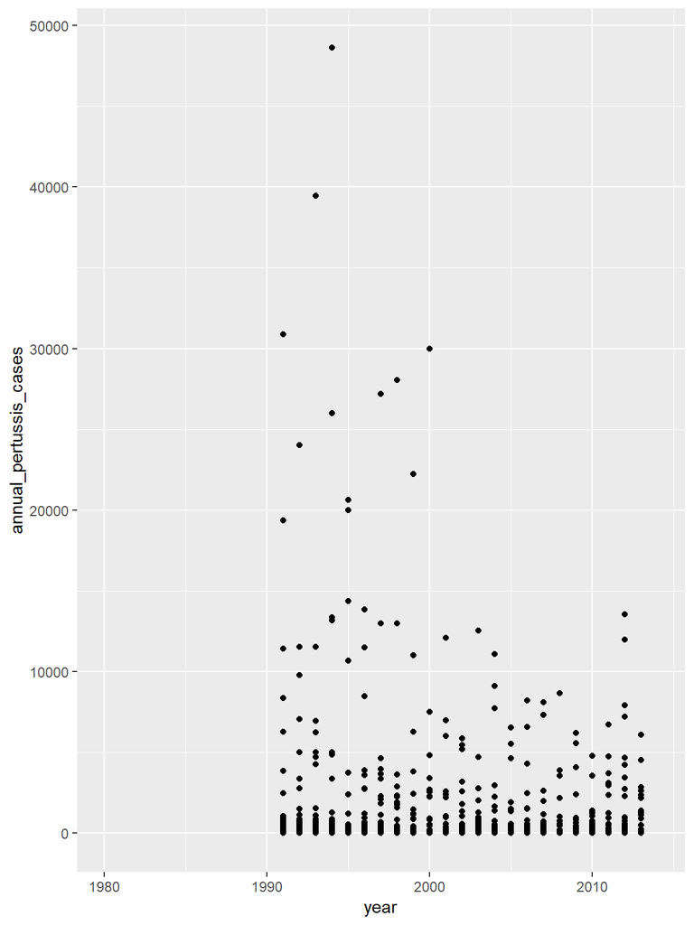

```r
pertussis_data_tidy %>%
  ggplot(aes(x = year, y = annual_pertussis_cases)) +
  geom_point(aes(position = "jitter" ))
```

## Grouping, filtering and selecting data with `{dplyr}`

Let’s calculate all cases for all countries, execept Bulgaria in the ninetees. Which countrie(s) has/have the highest number of cases? Which the lowest?

```r
pertussis_data_tidy$year[1]
```

```
## [1] "1980-01-01"
```

```r
ninetees <- c("1991-01-01", "1992-01-01", "1993-01-01", "1994-01-01", "1995-01-01", "1996-01-01", "1997-01-01", "1998-01-01", "1999-01-01")

ninetees_summary <- pertussis_data_tidy %>%
  dplyr::select(country, year, annual_pertussis_cases) %>%
  mutate(year = as.character(year)) %>%
  dplyr::filter(year %in% ninetees) %>%
  dplyr::filter(country != "Bulgaria") %>%
  group_by(country) %>%
  summarise(all_cases_ninetees = sum(annual_pertussis_cases, na.rm = TRUE)) %>%
  arrange(desc(all_cases_ninetees))
```

## Nintees data

```r
ninetees_summary
```

```
## # A tibble: 52 x 2
##    country                                              all_cases_ninetees
##    <chr>                                                             <int>
##  1 Russian Federation                                               254885
##  2 Switzerland                                                      104500
##  3 Sweden                                                            73909
##  4 Italy                                                             73064
##  5 Spain                                                             40317
##  6 United Kingdom of Great Britain and Northern Ireland              30736
##  7 Ukraine                                                           25170
##  8 Netherlands                                                       16738
##  9 Poland                                                             8621
## 10 Romania                                                            7447
## # ... with 42 more rows
```

```r
tail(ninetees_summary)
```

```
## # A tibble: 6 x 2
##   country    all_cases_ninetees
##   <chr>                   <int>
## 1 San Marino                 16
## 2 Luxembourg                  9
## 3 Andorra                     0
## 4 Germany                     0
## 5 Monaco                      0
## 6 Montenegro                  0
```

## Exploratory Data Analysis

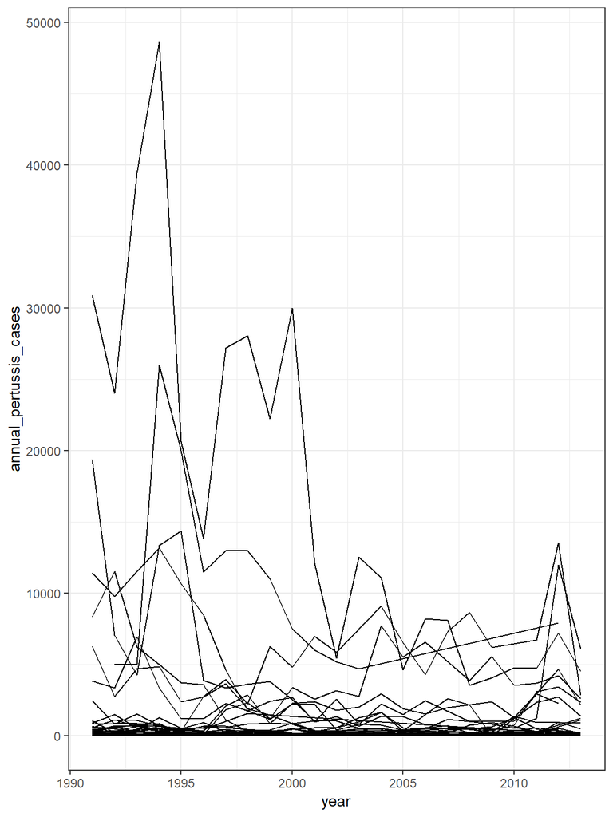

## Transform y-scale to log10, `colour = country`

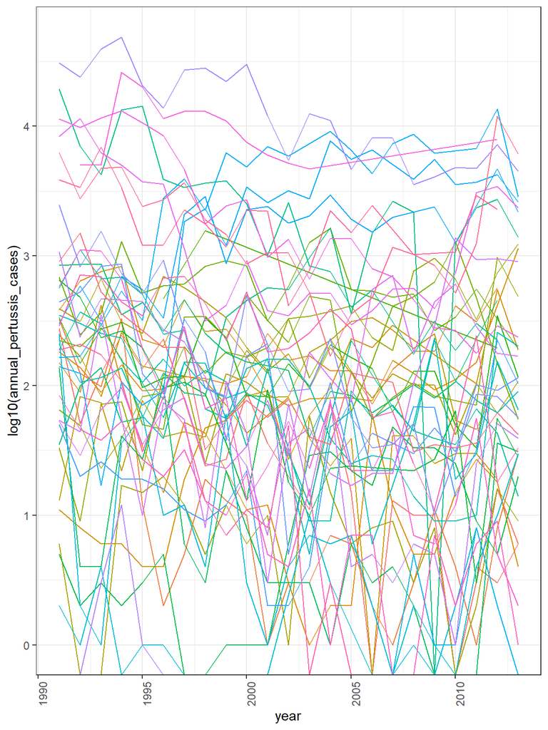

This is a messy graph indeed!!

## Adding a linear regression model for “Netherlands”

To reduce the data in the graph we can look at individual countries.

```r
pertussis_data_tidy$country %>% as_factor() %>% levels()
```

```
##  [1] "Albania"
##  [2] "Andorra"
##  [3] "Armenia"
##  [4] "Austria"
##  [5] "Azerbaijan"
##  [6] "Belarus"
##  [7] "Belgium"
##  [8] "Bosnia and Herzegovina"
##  [9] "Bulgaria"
## [10] "Croatia"
## [11] "Cyprus"
## [12] "Czech Republic"
## [13] "Denmark"
## [14] "Estonia"
## [15] "Finland"
```

[output cut: 38 more lines]

```r
## filter data for the Nethelands
nl_data <- pertussis_data_tidy %>%
  dplyr::filter(country == "Netherlands")
```

## Plot data only NL

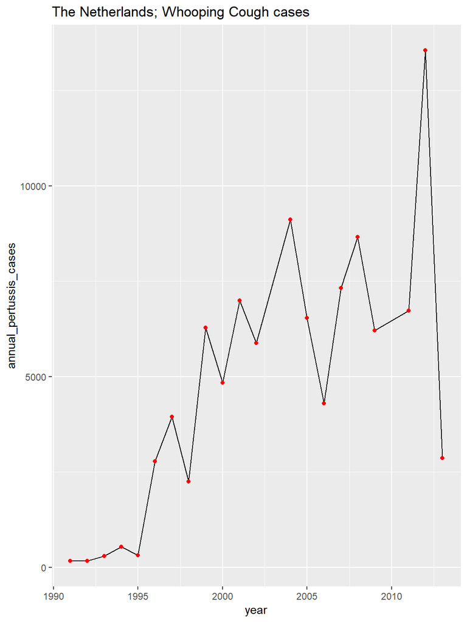

```r
nl_data %>%
  na.omit() %>% ## for sake of simplicity we remove the years that are missing
  ggplot(aes(x = year,
             y = annual_pertussis_cases)) +
  geom_line() +
  geom_point(colour = "red") +
  ggtitle("The Netherlands; Whooping Cough cases")
```

## Plot linear model for NL

```r
nl_model <- lm(
  annual_pertussis_cases ~ year,
  data = nl_data %>%
    na.omit()
)

## plot model for NL
plot_model <- nl_data %>%
  na.omit() %>%
  add_predictions(nl_model) %>%
  ggplot(aes(x = year,
             y = pred)) +
  geom_line() +
  ggtitle("Linear trend") +
  geom_point(
    data = nl_data,
    aes(x = year,
    y = annual_pertussis_cases),
    colour = "red") +
  geom_line(
    data = nl_data %>% na.omit, ## note the pipe to remove NA
    aes(x = year,
        y = annual_pertussis_cases),
    colour = "red",
    linetype = "dashed"
)
```

## Show model plot

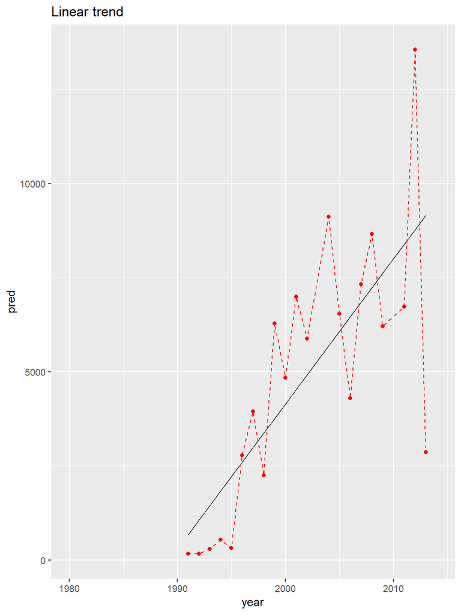

```r
plot_model
```

## Plot residuals

```r
plot_res <- nl_data %>%
  na.omit() %>%
  add_residuals(nl_model) %>%
  ggplot(aes(year, resid)) +
  geom_hline(yintercept = 0, colour = "white", size = 3) +
  geom_line() +
  ggtitle("Remaining pattern")
```

## Plot residuals

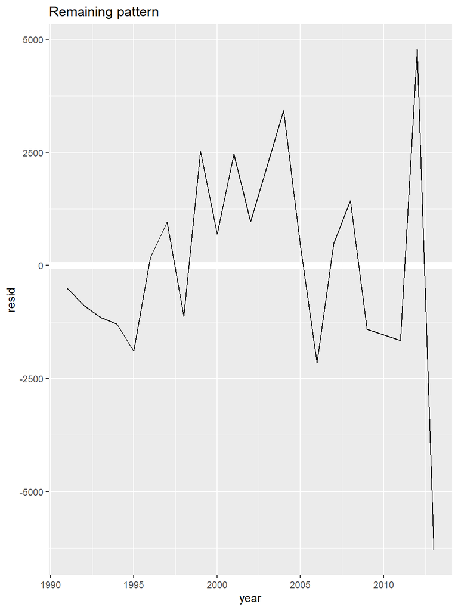

```r
plot_res
```

## How ‘good’ is this model?

```r
## tidyverse innovation
nl_model %>% broom::tidy()
```

```
## # A tibble: 2 x 5
##   term        estimate std.error statistic   p.value
##   <chr>          <dbl>     <dbl>     <dbl>     <dbl>
## 1 (Intercept) -7425.    2527.        -2.94 0.00844
## 2 year            1.06     0.214      4.92 0.0000941
```

```r
## classical R output
summary(nl_model)
```

```
##
## Call:
## lm(formula = annual_pertussis_cases ~ year, data = nl_data %>%
##     na.omit())
##
## Residuals:
##     Min      1Q  Median      3Q     Max
## -6297.3 -1292.9   178.5   966.4  4783.0
##
## Coefficients:
##               Estimate Std. Error t value Pr(>|t|)
## (Intercept) -7425.3054  2527.0515  -2.938  0.00844 **
## year            1.0557     0.2144   4.925 9.41e-05 ***
## ---
## Signif. codes:  0 '***' 0.001 '**' 0.01 '*' 0.05 '.' 0.1 ' ' 1
##
## Residual standard error: 2405 on 19 degrees of freedom
## Multiple R-squared:  0.5607, Adjusted R-squared:  0.5376
## F-statistic: 24.25 on 1 and 19 DF,  p-value: 9.41e-05
```

## How can we apply this model to `every` country

without doing the above 53 times.

## Split the data by country and apply the model to each subset

- In fact, each country is a dataframe
- We can subset the original dataframe into seperate dataframes for each country

## The classical way:

`split()` >> `apply()` >> `combine()`

```r
pertussis_data_tidy_split <- split(pertussis_data_tidy,
                                   pertussis_data_tidy$country)
head(pertussis_data_tidy_split[[1]], 2)
```

```
## # A tibble: 2 x 4
##     key country year       annual_pertussis_cases
##   <dbl> <chr>   <date>                      <int>
## 1     2 Albania 1980-01-01                     NA
## 2     2 Albania 1991-01-01                    275
```

But there is a better way in the `{tidyverse}` Here we combine `{tidyr}`, `{purrr}` and `{broom}`

## **Discuss with your neighbour**:

- What could be the downside for the `split()` >> `apply()` >> `combine()` approach?

## Better way to keep track of your results and models

1. Write functions that plot and model the data of each subset
2. Group the data by the subsetting factor (in our case this could be `country` or even `year`
3. Nest the grouped data into a dataframe (inside a list column) *Are you following?*
4. Apply the functions to your list column (by iteration, using the `map()` functions)
5. Store the results back into the dataframe as a new list column
6. Explore the results inside one big dataframe, the way you are used to

## Creating a list column with each country as an element in the list

We also remove the NAs for now.

```r
nested_pertussis <- pertussis_data_tidy %>%
  na.omit() %>%
  dplyr::select(country, year, annual_pertussis_cases) %>%
  group_by(country) %>%
    nest

head(nested_pertussis, 2) ## you see the grouping by country
```

```
## # A tibble: 2 x 2
##   country data
##   <chr>   <list>
## 1 Albania <tibble [22 x 2]>
## 2 Armenia <tibble [23 x 2]>
```

```r
head(nested_pertussis$data[[1]], 2) ## you get the individual countries
```

```
## # A tibble: 2 x 2
##   year       annual_pertussis_cases
##   <date>                      <int>
## 1 1991-01-01                    275
## 2 1992-01-01                     51
```

## **Discuss with you neighbour**

- How would you label the idividual elements of the list column (`$data`)?

## Linear model for each country

First we write a function that creates our linear model

```r
country_model_lm <- function(df){
  model <- lm(
    annual_pertussis_cases ~ year,
    data = df)
  return(model)
}
```

## Iterate the model function over nested `$data` with `purrr::map()`

```r
models <- map(
  nested_pertussis$data, country_model_lm
  )
```

## Keep it togetheR

- We have the models now
- It is better to store them together with the data
- Do that by using `dplyr::mutate()`

## Create an additional list-column on the basis of an existing one

```r
nested_pertussis <- nested_pertussis %>%
  mutate(models_lm = map(data, country_model_lm))
```

## Adding residuals to all the models

```r
nested_pertussis <- nested_pertussis %>%
  mutate(
    resids = map2(data, models_lm, add_residuals)
  )
```

## **Discuss with your neighbour**

- What type of arguments does the function `map2()` take?
- How would you find more information?

## Unnest the residuals

```r
resids <- nested_pertussis %>%
  unnest(resids)
```

## Plotting all residuals

```r
plot_all_resids <- resids %>%
  ggplot(aes(year, resid)) +
    geom_line(aes(group = country, colour = country), alpha = 0.8) +
    geom_smooth(se = FALSE) +
  theme_bw() +
  theme(legend.position="none") +
  facet_wrap( ~ country) +
 theme(axis.text.x = element_text(angle = 90, hjust = 1))
```

## What can we conclude from this graph?

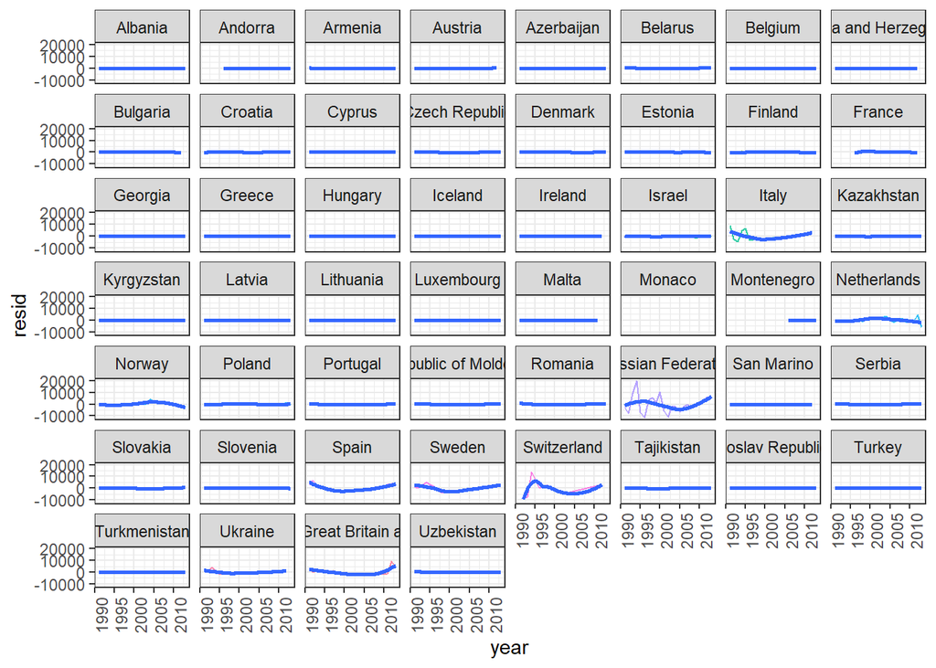

```r
plot_all_resids
```

## Extracting information from a list column *ADVANCED*

## Looking at quantative statistical measures for model quality

```r
r_squared <- nested_pertussis %>%
  mutate(glance = map(models_lm, broom::glance)) %>%
  unnest(glance, drop = TRUE) %>%
  select(country, r.squared, AIC, BIC) %>%
  arrange(r.squared)
```

## Plotting r.sqared values

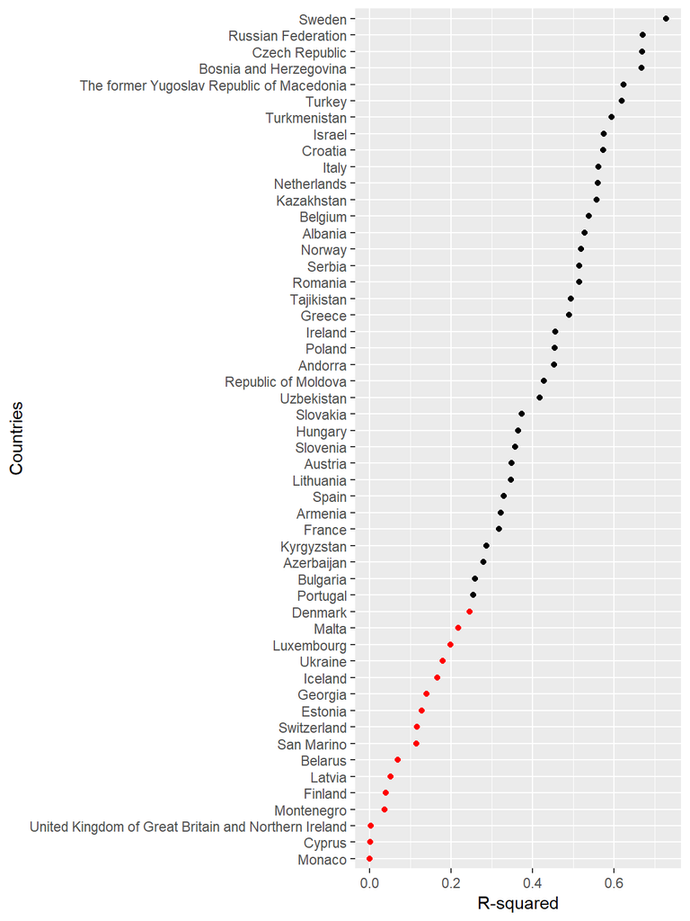

```r
r_squared %>%
  ggplot(aes(x = reorder(as_factor(country), r.squared),
             y = r.squared)) +
  geom_point() +
  coord_flip() +
  ylab("R-squared") +
  xlab("Countries") +
  geom_point(data = filter(r_squared, r.squared <= 0.25), colour = "red")
```

## Plotting pertussis cases for countries with low r.squared over time

1. Filter countries with `r.squared` <= 0.25
2. Put countries in vector
3. Plot data

## Step 1

```r
low_r_squared <- r_squared %>%
  dplyr::filter(r.squared <= 0.25) %>%
  dplyr::select(country)
low_r_squared <- low_r_squared$country
```

## Step 2

```r
low_r_squared_nested <- nested_pertussis %>%
  dplyr::filter(country %in% low_r_squared) %>%
  select(country, data) %>%
  unnest()
```

## Step 3

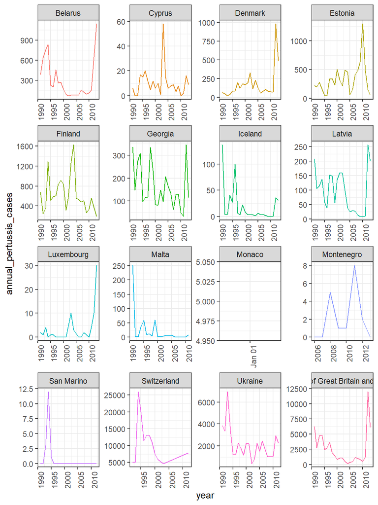

```r
low_r_squared_nested %>%
  ggplot(aes(x =year, y = annual_pertussis_cases)) +
  geom_line(aes(group = country, color = country)) +
    theme_bw() +
  theme(legend.position="none") +
  facet_wrap( ~ country, scales = "free") +
 theme(axis.text.x = element_text(angle = 90, hjust = 1))
```

What is happening with the pertussis vaccination grade over the past 8 years?

## Storing ggplot2 objects in a list-column

1. Create a function that makes the plot
2. Test function on single dataframe
3. Apply the function using `mutate()` and `map()` to all dataframes or models

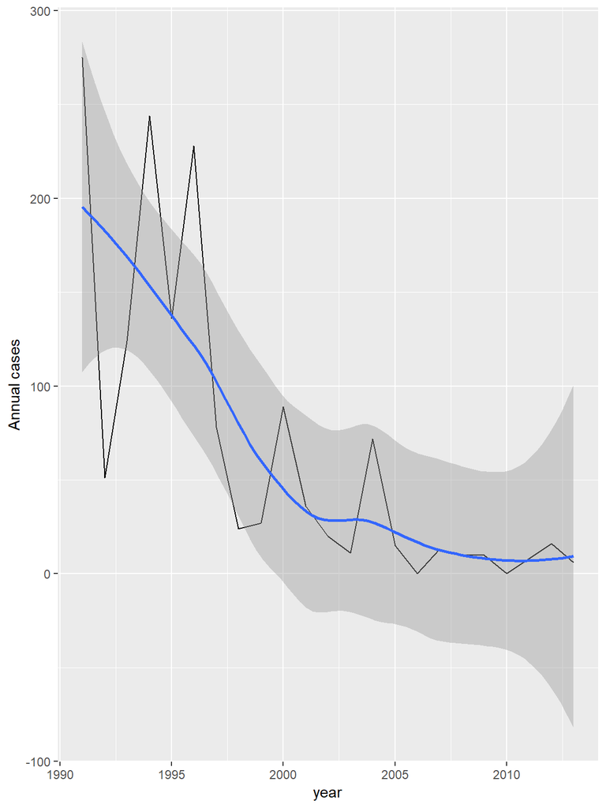

```r
## dummy variable
df <- nested_pertussis$data[[1]]
plot_country <- function(df){

  df %>%
    ggplot(aes(x = year,
           y = annual_pertussis_cases)) +
    geom_line() +
    geom_smooth() +
    ylab("Annual cases")

}

## test function
plot_country(df = df)
```

## Apply plotting function to nested data

```r
nested_pertussis <- nested_pertussis %>%
  mutate(plots_cases_over_time = map(data,
                                     plot_country))
```

## Add countries as names to nest-column

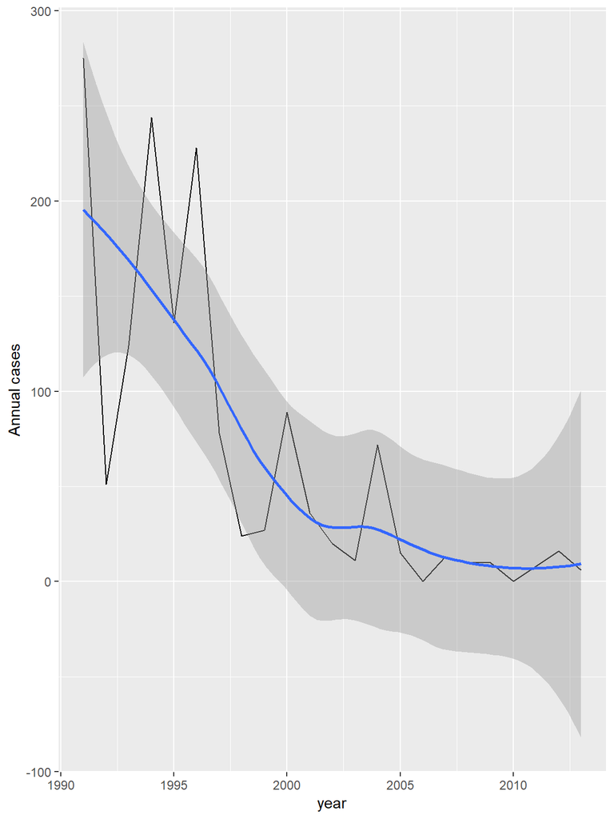

```r
names(nested_pertussis$plots_cases_over_time) <-
  c(nested_pertussis$country)

nested_pertussis$plots_cases_over_time[1]
```

## Pull out “The Netherlands”

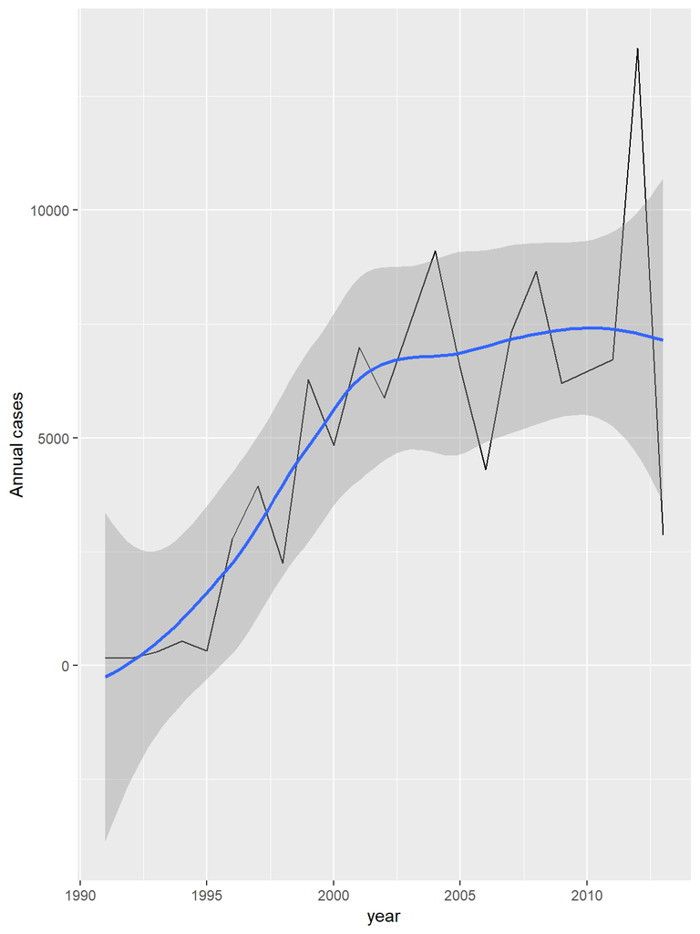

```r
nested_pertussis$plots_cases_over_time$Netherlands
```

## Plotting a panel of 4 graphs

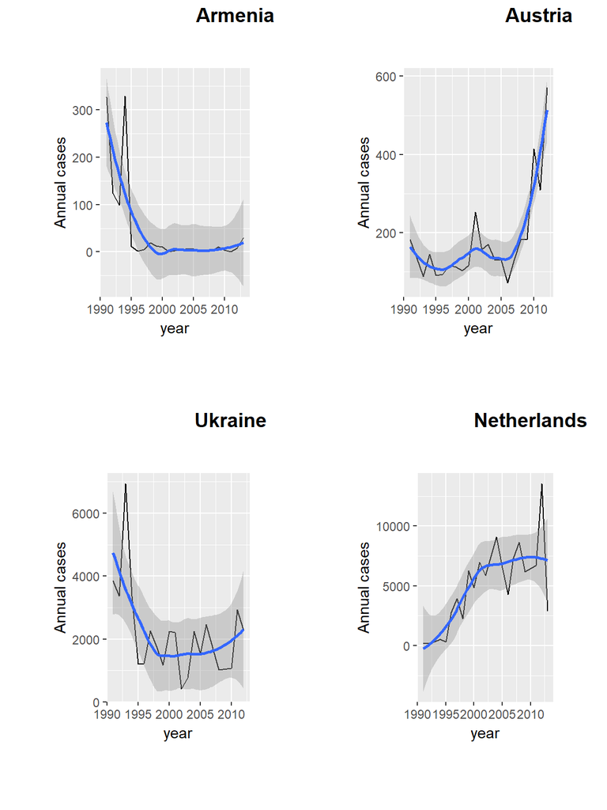

## Literature

For some background on the pattern we are seeing

- https://www.scientificamerican.com/article/why-whooping-cough-vaccines-are-wearing-off/
- http://outbreaknewstoday.com/pertussis-cases-up-significantly-in-the-eu-netherlands-and-uk-worst-hit-55315/

## Exploring many more models

Let’s add a quadratic model in the mix. Assume we want to explore non-linear relationships in this dataset

```r
non_linear_model <- function(df, model_params){

  nl_model <- lm(
    annual_pertussis_cases ~ poly(year,
                                  model_params),
                 data = df)

  return(nl_model)
}
```

## Creating a safe version of this function

```r
safe_non_linear <- purrr::safely(non_linear_model)
## apply test:
df = nested_pertussis$data[[1]]
test_non_linear <-  df %>% non_linear_model(df = .,
                                            model_params = 2)
```

## Test function on one country

```r
test_non_linear %>% broom::glance()
```

```
## # A tibble: 1 x 11
##   r.squared adj.r.squared sigma statistic p.value    df logLik   AIC   BIC
##       <dbl>         <dbl> <dbl>     <dbl>   <dbl> <int>  <dbl> <dbl> <dbl>
## 1     0.607         0.566  55.0      14.7 1.39e-4     3  -118.  244.  248.
## # ... with 2 more variables: deviance <dbl>, df.residual <int>
```

## Apply model to all countries

We rerun the steps above to add this new model and new graphs to the nested dataframe

Add new model to the nested table

```r
nested_pertussis <- nested_pertussis %>%
  mutate(models_nl_2 = map(data, safe_non_linear,
                          model_params = 2))

nested_pertussis$models_nl_2 <- transpose(nested_pertussis$models_nl_2)
```

## Set names to elements in the list-column

To be able to `pluck()` by name later

```r
names(nested_pertussis$models_nl_2$result) <- nested_pertussis$country
```

## Pluck results in new list-column

```r
nested_pertussis$models_nl_2$result
```

```
## $Albania
##
## Call:
## lm(formula = annual_pertussis_cases ~ poly(year, model_params),
##     data = df)
##
## Coefficients:
##               (Intercept)  poly(year, model_params)1
##                      67.5                     -278.3
## poly(year, model_params)2
##                     107.5
##
##
## $Armenia
##
## Call:
## lm(formula = annual_pertussis_cases ~ poly(year, model_params),
##     data = df)
##
## Coefficients:
##               (Intercept)  poly(year, model_params)1
##                      44.3                     -251.9
## poly(year, model_params)2
##                     228.1
##
##
## $Austria
##
## Call:
## lm(formula = annual_pertussis_cases ~ poly(year, model_params),
##     data = df)
##
## Coefficients:
##               (Intercept)  poly(year, model_params)1
##                     177.0                      320.1
## poly(year, model_params)2
##                     290.3
##
##
## $Azerbaijan
```

[output cut: 609 more lines]

```
##
## $Monaco
## NULL
##
## $Montenegro
##
## Call:
## lm(formula = annual_pertussis_cases ~ poly(year, model_params),
##     data = df)
##
## Coefficients:
##               (Intercept)  poly(year, model_params)1
##                     2.125                      1.465
## poly(year, model_params)2
##                    -3.627
```

```r
nested_pertussis <- nested_pertussis %>%
  mutate(statistics_nl = pluck(models_nl_2, "result"))
nested_pertussis$statistics_nl[[1]]
```

```
##
## Call:
## lm(formula = annual_pertussis_cases ~ poly(year, model_params),
##     data = df)
##
## Coefficients:
##               (Intercept)  poly(year, model_params)1
##                      67.5                     -278.3
## poly(year, model_params)2
##                     107.5
```

## Tidy the list-column with `{broom}`

```r
nested_pertussis <- nested_pertussis %>%
  mutate(parameters_nl = map(statistics_nl, glance))
```

## Looking at quantative statistical measures for model quality

```r
r_squared_nl <- nested_pertussis %>%
  select(country, parameters_nl) %>%
  unnest()
```

## Plotting r.sqared values

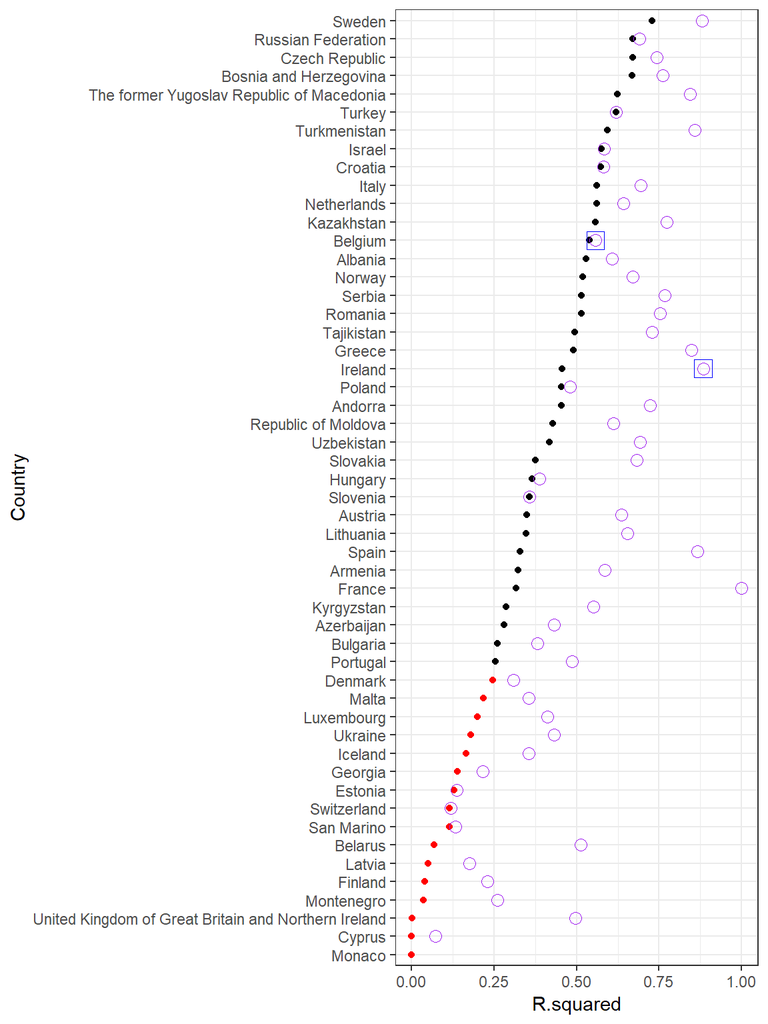

## Let’s examine two models for two countries where the non-linear did and did not not improve the R.squared: Ireland (improved) and Belgium (not-improved)

```r
x <- nested_pertussis %>%
  select(country,
         data,
         models_lm,
         statistics_nl) %>%
  gather(models_lm:statistics_nl, key = "models", value = "model_params") %>%
 print()
```

```
## # A tibble: 104 x 4
##    country                data              models    model_params
##    <chr>                  <list>            <chr>     <list>
##  1 Albania                <tibble [22 x 2]> models_lm <S3: lm>
##  2 Armenia                <tibble [23 x 2]> models_lm <S3: lm>
##  3 Austria                <tibble [22 x 2]> models_lm <S3: lm>
##  4 Azerbaijan             <tibble [23 x 2]> models_lm <S3: lm>
##  5 Belarus                <tibble [22 x 2]> models_lm <S3: lm>
##  6 Belgium                <tibble [21 x 2]> models_lm <S3: lm>
##  7 Bosnia and Herzegovina <tibble [19 x 2]> models_lm <S3: lm>
##  8 Bulgaria               <tibble [22 x 2]> models_lm <S3: lm>
##  9 Croatia                <tibble [23 x 2]> models_lm <S3: lm>
## 10 Cyprus                 <tibble [23 x 2]> models_lm <S3: lm>
## # ... with 94 more rows
```

## Remove ‘empty model’

```r
ind <- x$model_params == "NULL"
#ind <- x$data == "NULL"
x <- x[!ind, ]
```

## Add prediction-list column

```r
predictions <- x %>%
#  filter(country == "Czech Republic") %>%
  mutate(predictions = map2(data, model_params, add_predictions,
         var = "annual_pertussis_cases")) %>%
  filter(country == "Ireland" |
         country == "Belgium") %>%
  select(country, data, predictions)
```

## Set names

```r
names(predictions$predictions) <- predictions$country
```

## Belgium

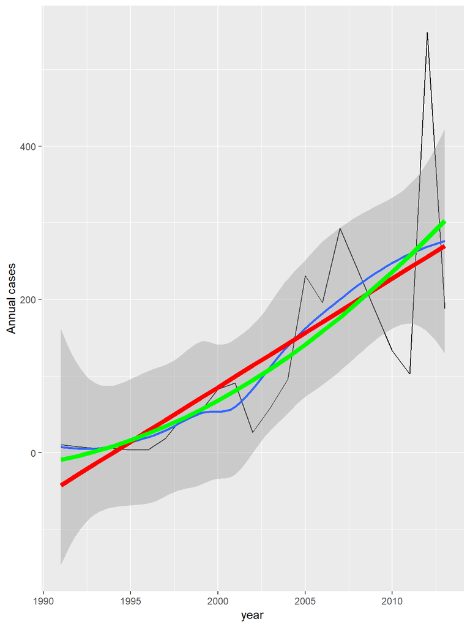

```r
nested_pertussis$plots_cases_over_time$Belgium +
  geom_line(data = predictions$predictions[[1]], colour = "red", size = 2) +

  geom_line(data = predictions$predictions[[3]], colour = "green", size = 2)
```

## Ireland

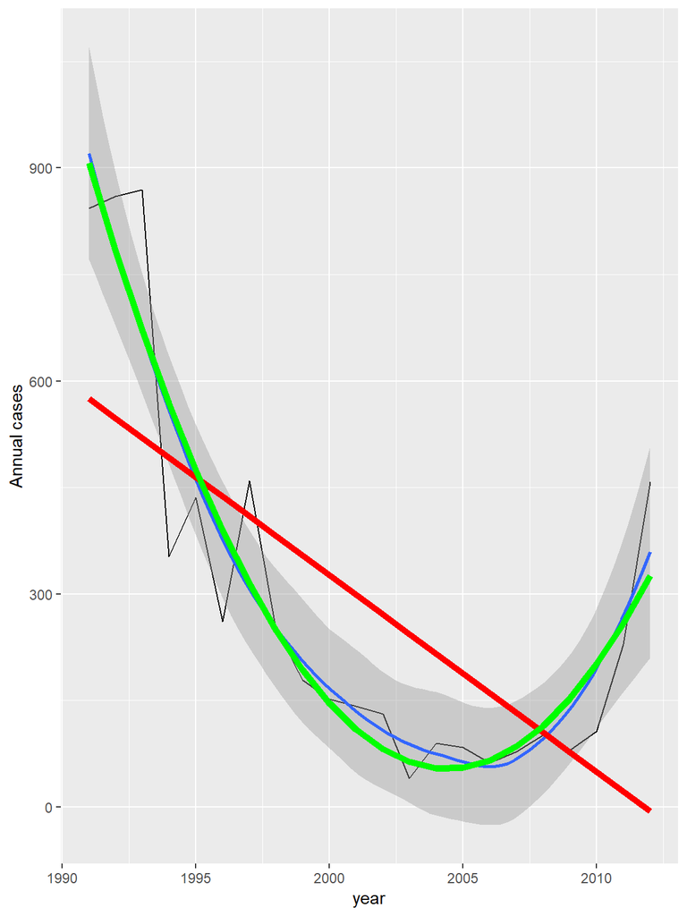

```r
nested_pertussis$plots_cases_over_time$Ireland+
  geom_line(data = predictions$predictions[[2]], colour = "red", size = 2) +

  geom_line(data = predictions$predictions[[4]], colour = "green", size = 2)
```

## Disclaimer & Licence

_The work in this presentation has been adapted from many sources as mentioned in slide ‘Credits’. For a full reference list see the ‘REFERENCES.txt’ document in the github repo https://www.github.com/usashogeschoolutrecht/surf_research_bootcamp_2018

The work presented here may be shared, remixed or adapted as long as the original references and the authors of this document are mentioned in the redistribution: CC BY-SA